# Part II - (Bike Sharing System Trips distribution)

## by (Martha Mwangi)

## Investigation Overview

In The investigation, I wanted to look at when the most trips are taken in terms of time of the day, day of the week and month of the year in a bike sharing sharing system in San Francisco Bay Area. Also I wanted to look at on whether the users were customers or subscribers.

## Dataset Overview

Ford GoBike System Data is a dataset that consists information of over 180,000 entries about individual rides made in a bike sharing system in San Francisco Bay Area.

## (Visualization 1)

From the chart, it shows that the most trips were taken in the evening hours of 1700 Hrs and at 0800Hrs with over 20,000 trips and reduced as the day progressed towards the morning hours with the least trips being recorded at 0300 hours of just 164 trips.

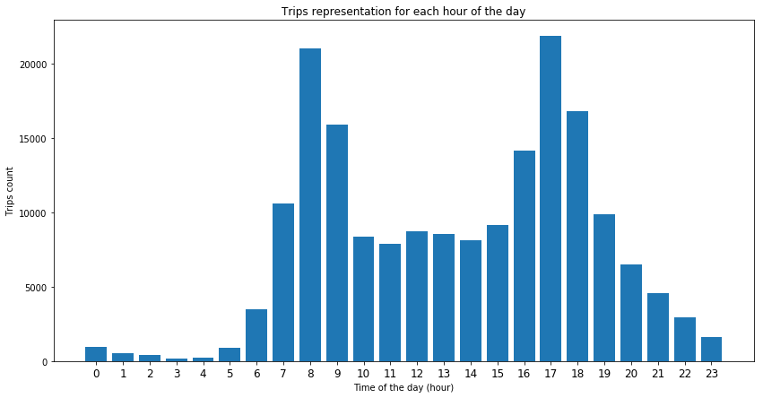

## (Visualization 2)

[figure not shown]

## (Visualization 3)

The plot goes to show that, most trips were taken by subscribers as has been seen in previous deduction in the analysis process. Days that registered more trips is highly represented by subscribers which is suffice t say, subscribers took the most trips.

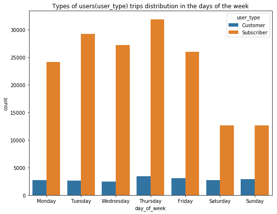